# Problem Set 4

BUS 696 Problem Set Template

Ryan Richardson

```r
getwd()
```

```
## [1] "E:/Chapman/graduate-work/bs-696-bus-ml/HW4"
```

```r
# load all your libraries in this chunk
library('tidyverse')
library('here')
library('forcats')
library('rsample')
library('plotROC')
library('glmnet')
library('glmnetUtils')
library('ggridges')
library('randomForest')

# note, do not run install.packages() inside a code chunk. install them in the console outside of a code chunk.
```

## Question 1

```r
options(scipen = 50)
set.seed(1861)
movies <- read.csv(here::here("datasets", "IMDB_movies.csv"))
movies_clean <- movies %>%
    # filter out some movies with missing values or
    # outliers
filter(budget < 4e+08, content_rating != "", content_rating !=
    "Not Rated", plot_keywords != "") %>%
    # clean genre and plot
mutate(genre_main = unlist(map(strsplit(as.character(.$genres),
    "\\|"), 1)), plot_main = unlist(map(strsplit(as.character(.$plot_keywords),
    "\\|"), 1)), grossM = gross/1e+06, budgetM = budget/1e+06) %>%
    mutate(genre_main = fct_lump(genre_main, 7), plot_first = fct_lump(plot_main,
        20), content_rating = fct_lump(content_rating, 4), country = fct_lump(country,
        8), language = fct_lump(language, 4), cast_total_facebook_likes000s = cast_total_facebook_likes/1000) %>%
    drop_na()

top_director <- movies_clean %>%
    group_by(director_name) %>%
    summarize(num_films = n()) %>%
    top_frac(0.1) %>%
    mutate(top_director = 1) %>%
    select(-num_films)

movies_clean <- movies_clean %>%
    left_join(top_director, by = "director_name") %>%
    mutate(top_director = replace_na(top_director, 0)) %>%
    select(-c(director_name, actor_2_name, gross, genres, actor_1_name,
        movie_title, actor_3_name, plot_keywords, movie_imdb_link,
        budget, color, aspect_ratio, plot_main, actor_3_facebook_likes,
        actor_2_facebook_likes, color, num_critic_for_reviews,
        num_voted_users, num_user_for_reviews, actor_2_facebook_likes))

sapply(movies_clean %>%
    select_if(is.factor), table)
```

```
## $country
##
## Australia    Canada    France   Germany Hong Kong     Spain        UK
##        39        57        97        79        13        19       315
##       USA     Other
##      2973       119
##
## $language
##
##  English   French Mandarin  Spanish    Other
##     3575       32       13       22       69
##
## $content_rating
##
##     G    PG PG-13     R Other
##    87   565  1305  1693    61
##
## $genre_main
##
##    Action Adventure Biography    Comedy     Crime     Drama    Horror
##       952       367       204       979       250       652       163
##     Other
##       144
##
## $plot_first
##
##            1950s            1970s            actor african american
##               18               18               24               24
##            alien        apartment             army         assassin
##               69               19               20               26
##             baby             bank              bar       basketball
##               22               19               18               18
##           battle            beach      best friend  box office flop
##               26               19               32               28
##              boy        christmas              cia          college
##               36               18               19               22
##            death           friend            Other
##               40               21             3155
```

```r
movies_split <- initial_split(movies_clean, prop = 0.75)

movies_train <- training(movies_split)
movies_test <- testing(movies_split)
```

1b) The keywords battle, friend, and college are the plot keywords with teh most blockbusters, with beach , alien, and actor having small numbers close to being a blockbuster.

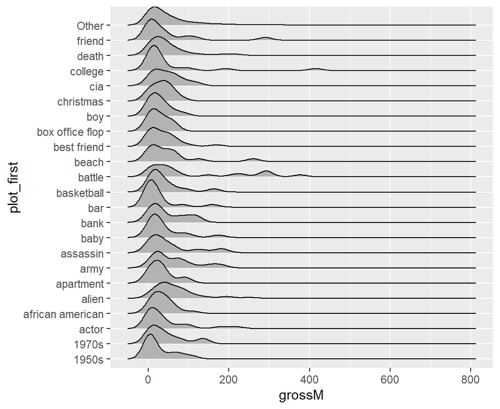

```r
ggplot(movies_train, aes(x=grossM,y=plot_first)) + geom_density_ridges()
```

1d) MTRY is used to identify how many splits should be created at each level of the forest dependent, or, in essence, how many variables should be chosen at each level of the forest for that decision.

1e) If you set mtry = P then you will have only 1 forest used for tuning and will get the same results each time since the subset of variables ued for each iteration will always be the same, P.

1f) NTREE is how many different trees to try for a random forest. A lrager number of trees will generally allow the model to converge to a proper solution, while a lower number of trees may have a gerater error and not properly converge. However,a larger number of trees may increaes variance without increasing fitness.

1g) The effects of MTRY on model performance are not consistent and can vary wildly depending on the model. Generally, having a lower number of variables for each decision at each level of the forest will allow for more granular control over the predictions. While this may increase the bias and the number of trees needed, it should allow for decent convergence over time. Conversely, a large MTRY may not need as many trees but the variance induced by having so many vaariables at each level of the forest could lead to weird predictions or poor convergence. However, there is some literature that suggests no difference between high and low values for MTRY, so it’s best to test which value works best for the model.

1h) It depends on the model. If we are estimating grossM by plot_first, cast_total_facebook_likes, and top_director then MTRY should probably be 2, as root(3) is closer to 2 than it is to 1. If we are estimating on additional variables, including the factors, then we should be using root(62-6) (due to base levels for the factors and our output grossM), which means root(56) which is approximately 7.483, so we should use 7 for mtry.

1i) Hyperparameterse are values used to change how quickly our model ‘learns’ or changes across each iteration. These are not directly used as an outcome or a predictor, but instead used at a high level to either change how predicotrs are chosen, what weights predictors are given, and similar tweaks that modify the end effect on our output variable for that generation. Hyper parameters can be constant through each iteration, or can be modified throughout the learning process. the hyperparameters in our random forest model are MTRY and NTREE

```r
rf_fit_ryan_richardson = randomForest(grossM ~ ., data=movies_train, mtry=7,ntree=200, importance=TRUE)
rf_fit_ryan_richardson$importance
```

```
##                                  %IncMSE IncNodePurity
## country                         85.89222     215934.35
## title_year                     409.50804     630993.82
## imdb_score                     821.51247    1489037.35
## language                         3.11772      17302.19
## duration                       178.72291     874586.31
## content_rating                 335.56943     564062.38
## movie_facebook_likes           539.28598    1233526.37
## director_facebook_likes         88.17567     511776.46
## cast_total_facebook_likes      322.59581     643354.15
## facenumber_in_poster            24.14725     195352.98
## actor_1_facebook_likes         247.03725     381511.02
## genre_main                     247.15501     585445.96
## budgetM                       2598.93722    4462675.51
## plot_first                      20.02866     218428.78
## cast_total_facebook_likes000s  409.60075     696821.69
## top_director                   119.77057     217317.02
```

1k) MSE decreases exponentially as our number of trees increases. Based on this information we should use around 75-100 trees, as that more than that does not significantly reduce our prediction error.

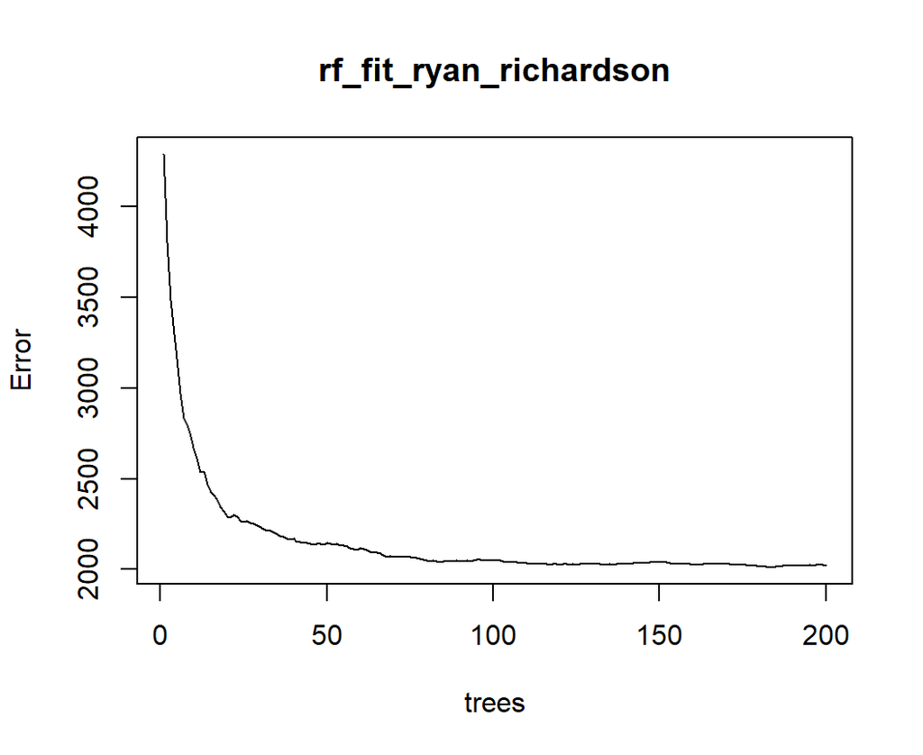

```r
plot(rf_fit_ryan_richardson)
```

1l) In Bag predictions have an MSE of 386.499, Out of Bag have an MSE of 2023.174, and Test Preidctions have an MSE of 2110.787. What this tells me is that the model is likely not overfit as the OOB and test MSE are fairly close in magnitude, and the RMSE is even closer. As expected, the in bag error is very much smaller, indicating a high bias, which is expected for a random forest. Overall, I would say that the RMSE and MSE are fairly close to the values we see in our cross validated models, and as such a random forest should be fine for a regression problem such as identifying gross sales for a movie.

```r
in_bag = predict(rf_fit_ryan_richardson, movies_train, type="response")
out_of_bag = predict(rf_fit_ryan_richardson, type="response")
test_predictions = predict(rf_fit_ryan_richardson, movies_test, type="response")

print("IB")
```

```
## [1] "IB"
```

```r
mean((movies_train$grossM - in_bag)^2)
```

```
## [1] 386.4988
```

```r
sqrt(mean((movies_train$grossM - in_bag)^2))
```

```
## [1] 19.65957
```

```r
print("OOB")
```

```
## [1] "OOB"
```

```r
mean((movies_train$grossM - out_of_bag)^2)
```

```
## [1] 2023.174
```

```r
sqrt(mean((movies_train$grossM - out_of_bag)^2))
```

```
## [1] 44.9797
```

```r
print("Test")
```

```
## [1] "Test"
```

```r
mean((movies_test$grossM - test_predictions)^2)
```

```
## [1] 2110.787
```

```r
sqrt(mean((movies_test$grossM - test_predictions)^2))
```

```
## [1] 45.9433
```